# BCB420 Assignment 2: Differential Gene expression and Preliminary ORA- Dhanya Jagannathan

# Assignment 1 Recap

To recap, in Assignment 1, I (1) analysed information about the dataset I have chosen, and its associated publication, (2) mapped the expression data to HUGO gene symbols, (3) filtered out unncecessary genes, and (4) normalized the dataset. The following subsections go over these points in a bit more detail, and are taken from my Assignment 1. In addition, the code from my .rmd file includes code from A1- in order to regenerate the normalized counts matrix.

### Brief Introduction to the Data

The expression dataset that I had chosen is GSE221253, taken from the GEO expression data repository. The study associated with this dataset involved adoptive cell therapy. Adoptive cell therapy via tumor infiltrating lymphocytes (ACT-TIL) is a type of immunotherapy used to treat cancer. This [study](https://www.science.org/doi/10.1126/sciimmunol.adg7995) took samples from 13 patients having metastatic melanoma and performed RNAseq analysis, along with other analyses like spatial proteomics and scRNAseq, on tumor tissues before and after the cell therapy (pre- and post-ACT) in order to gain a better understanding of the interactions and cell states within the tumor microenvironment throughout treatment. For the RNAseq experiment, this resulted in a total of 26 samples, and 13 in each condition (two for each patient, and the experimental conditions being pre- and post-ACT treatment).

### Mapping to HUGO Gene Symbols

The first step from Assignment 1 was to map the expression data to HUGO gene symbols. Only 940 out of 19117 genes from our original gene expression raw file were unable to be mapped to HUGO gene symbols. This is actually not that bad!

### Dataset Filteration and Normalization

The next step in Assignment 1 was to filter out the genes with low counts and normalize our data. Filteration of outlier genes with low gene counts removed ~3678 genes from the expression dataset. Then, TMM normalization was performed to normalize the data. The plots (pre and post normalization + filtration) are shown below:

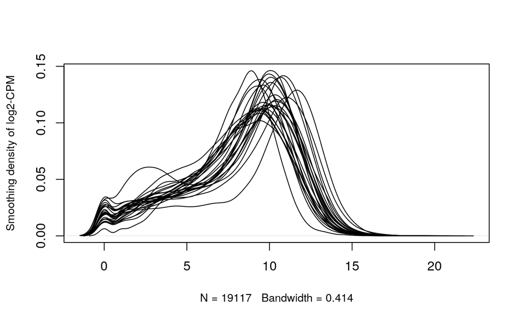

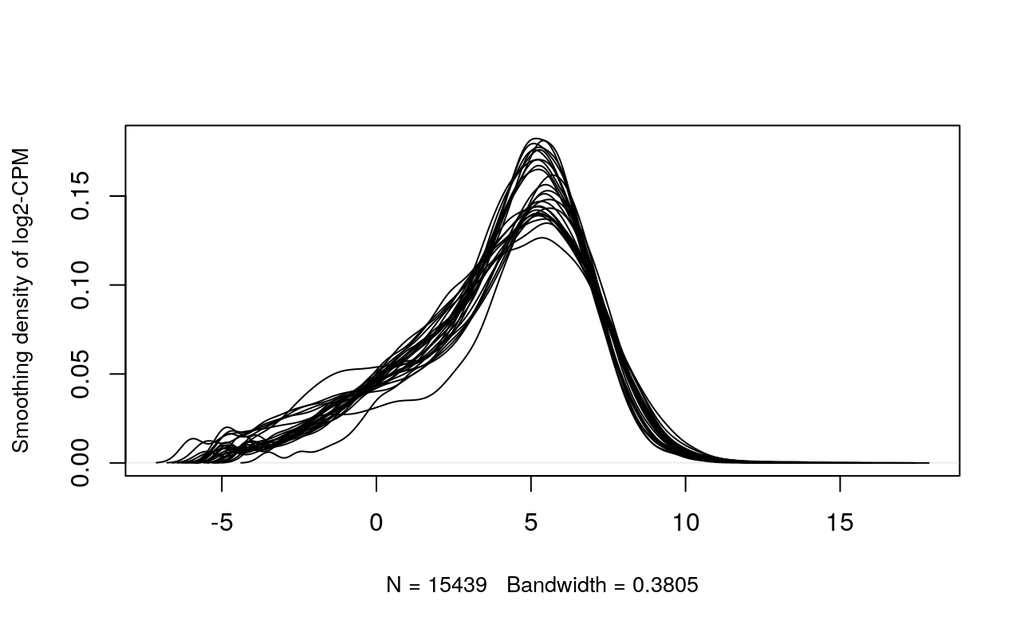

# Differential Gene Expression

The first step of Assignment 2 is to perform differential gene expression, to identify key genes that are differentially expressed between our subgroups. This involves (1) constructing our model design, (2) estimating the dispersion, (3) performing multiple hypothesis testing and using the Quasi liklihood model to calculate differential expression, and (4) generate a heatmap and MA plot of the data.

### Model Design

After inspection of the MDS plot (below), it doesn’t seem that there is a lot of clustering amongst pre-ACT and post-ACT samples. However, since the study associated with this data set aims to understand interactions and cell states within the tumor microenvironment throughout treatment, it makes the most sense to define the group for our model design, as the time of treatment (pre-ACT or post-ACT), as opposed to tumor type (since all samples are from the same tumor), or patient. So, I decided to make my model design based off of the time point the samples were collected (before ACT treatment and after ACT treatment). Here, we also define the DGEList.

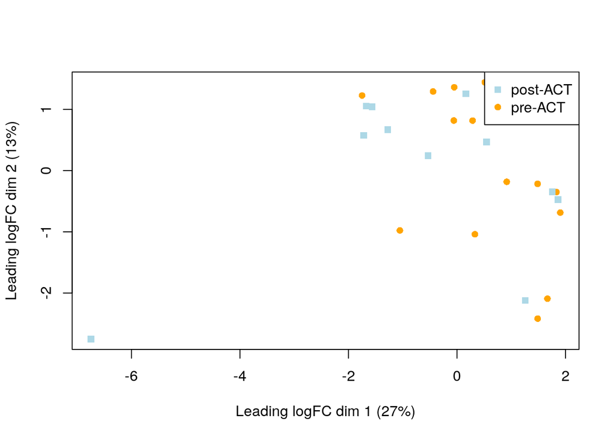

```
##    (Intercept) samplesInfoMatrix$timepre-ACT
## 1            1                             1
## 2            1                             0
## 3            1                             1
## 4            1                             0
## 5            1                             1
## 6            1                             0
## 7            1                             1
## 8            1                             0
## 9            1                             1
## 10           1                             0
## 11           1                             1
## 12           1                             0
## 13           1                             1
## 14           1                             0
```

[output cut: 17 more lines]

### Estimate Dispersion + Top Gene Hits

Here, we estimate the dispersion, fit the model to our specified model design, and then calculate differential expression using the Quasi liklihood model. The table below shows the top gene hits.

|  | logFC | logCPM | F | PValue | FDR |
| --- | --- | --- | --- | --- | --- |
| ALB | -14.893974 | 11.900720 | 40.50206 | 7.0e-07 | 0.0018536 |
| FOSB | 3.791452 | 5.261109 | 39.29955 | 9.0e-07 | 0.0018536 |
| FOS | 2.600458 | 7.410897 | 38.90495 | 1.0e-06 | 0.0018536 |
| FGB | -13.907270 | 10.372034 | 38.81796 | 1.1e-06 | 0.0018536 |
| FGA | -13.295751 | 9.650812 | 38.26330 | 1.2e-06 | 0.0018536 |
| ZC2HC1B | -2.871639 | 1.604275 | 37.93189 | 1.3e-06 | 0.0018536 |
| GC | -11.892857 | 7.806030 | 37.19659 | 1.5e-06 | 0.0018536 |
| APOH | -11.785979 | 7.789941 | 37.07206 | 1.5e-06 | 0.0018536 |
| KNG1 | -11.937946 | 8.299449 | 37.02790 | 1.5e-06 | 0.0018536 |
| ARG1 | -8.562373 | 5.402457 | 36.46001 | 1.8e-06 | 0.0018536 |

|  | x |
| --- | --- |
| 1 | BH |

|  | x |
| --- | --- |
| 1 | samplesInfoMatrix$timepre-ACT |

|  | x |
| --- | --- |
| 1 | glm |

### Multiple Hypothesis Testing

In the below code blocks, we compile all of the results, and find how many genes pass the threshold value, and how many genes pass correction.

How many genes pass the p-value threshold p < 0.05?

```
## [1] 4684
```

```
## [1] 1643
```

### MA Plot

Here is an MA plot that displays the differential gene expression between our two groups of samples: pre- and post- ACT.

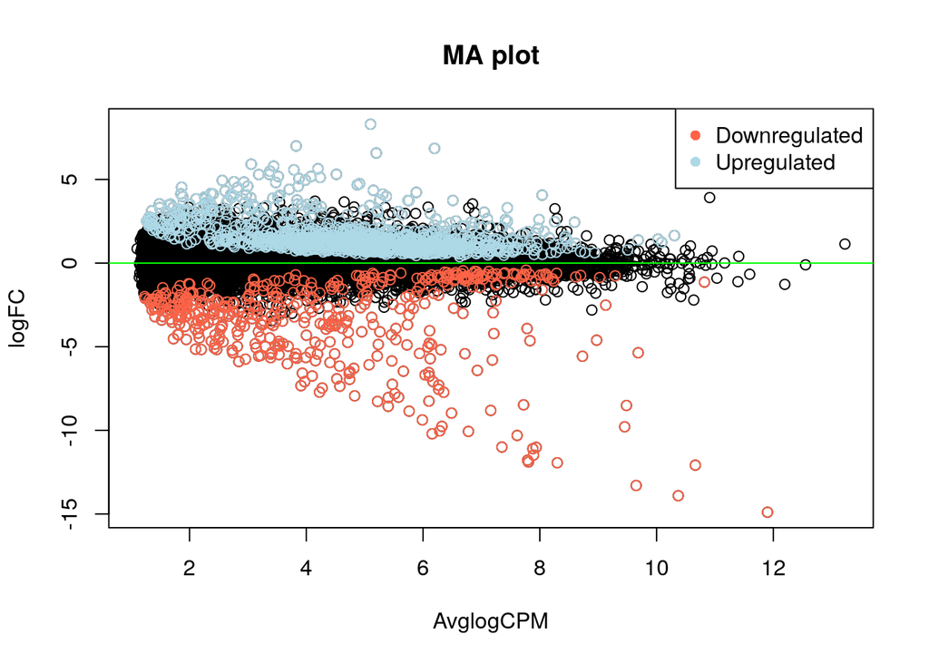

### Heat Map

The following codeblock generates a heatmap of our data, along with annotations, to see how the data seems to cluster. Based on what is shown in the heatmap below, there does seem to be some minimal clustering of genes that are overexpressed in some pre-ACT samples.

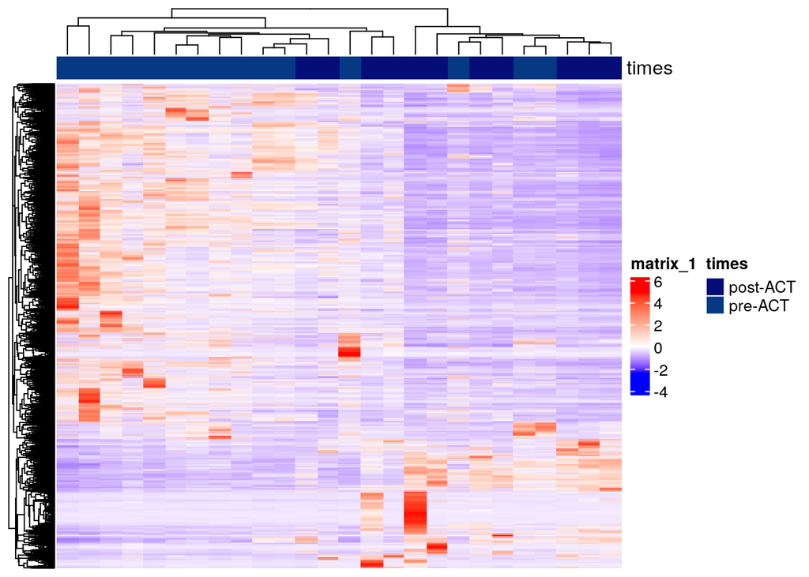

# Thresholded Over Representation Analysis

The last step of this assignment is to perform thresholded over-representation analysis (ORA). Essentially, our main goal here is to see whether our upregulated or downregulated genes all share some kind of common characteristic (maybe some of them are from the same pathway, etc). By doing this, we can then make conclusions about what kind of genes are overexpressed/underexpressed and ensure that it aligns with literature.

### Define All, Upregulated, Downregulated genes

```
## [1] "Number of upregulated genes"
```

```
## [1] 1170
```

```
## [1] "Number of downregulated genes"
```

```
## [1] 473
```

```
## [1] "Number of significant genes in total"
```

```
## [1] 1643
```

### Running G:profiler on All Significant Genes

Here, we run run g:profiler on the set of all significant genes that have a p-value of < 0.05 to perform a gene set enrichment analysis.

| query | significant | p_value | term_size | query_size | intersection_size | precision | recall | term_id | source | term_name | effective_domain_size | source_order | parents |
| --- | --- | --- | --- | --- | --- | --- | --- | --- | --- | --- | --- | --- | --- |
| query_1 | TRUE | 6.630947e-07 | 1494 | 1393 | 199 | 0.14285714 | 0.1331995 | GO:0044281 | GO:BP | small molecule metabolic process | 16178 | 11317 | GO:0008152 |
| query_1 | TRUE | 2.189967e-05 | 2145 | 1393 | 257 | 0.18449390 | 0.1198135 | GO:0009056 | GO:BP | catabolic process | 16178 | 3269 | GO:0008152 |
| query_1 | TRUE | 5.598736e-05 | 4941 | 1393 | 517 | 0.37114142 | 0.1046347 | GO:1901564 | GO:BP | organonitrogen compound metabolic process | 16178 | 22098 | GO:00068…. |
| query_1 | TRUE | 7.868727e-05 | 267 | 1393 | 51 | 0.03661163 | 0.1910112 | GO:0016053 | GO:BP | organic acid biosynthetic process | 16178 | 5145 | GO:00060…. |
| query_1 | TRUE | 9.388388e-05 | 764 | 1393 | 109 | 0.07824838 | 0.1426702 | GO:0006082 | GO:BP | organic acid metabolic process | 16178 | 1967 | GO:00442…. |
| query_1 | TRUE | 9.388388e-05 | 264 | 1393 | 50 | 0.03589375 | 0.1893939 | GO:0046394 | GO:BP | carboxylic acid biosynthetic process | 16178 | 12522 | GO:00160…. |

### Running G:profiler on the Upregulated Gene Set

In the codeblock below, we run g:profiler on the set of upregulated genes to perform a gene set enrichment analysis.

| query | significant | p_value | term_size | query_size | intersection_size | precision | recall | term_id | source | term_name | effective_domain_size | source_order | parents |
| --- | --- | --- | --- | --- | --- | --- | --- | --- | --- | --- | --- | --- | --- |
| query_1 | TRUE | 0.004049154 | 88 | 997 | 18 | 0.018054162 | 0.20454545 | GO:0042775 | GO:BP | mitochondrial ATP synthesis coupled electron transport | 16178 | 10709 | GO:0042773 |
| query_1 | TRUE | 0.004049154 | 4941 | 997 | 368 | 0.369107322 | 0.07447885 | GO:1901564 | GO:BP | organonitrogen compound metabolic process | 16178 | 22098 | GO:00068…. |
| query_1 | TRUE | 0.004049154 | 88 | 997 | 18 | 0.018054162 | 0.20454545 | GO:0042773 | GO:BP | ATP synthesis coupled electron transport | 16178 | 10707 | GO:00061…. |
| query_1 | TRUE | 0.004049154 | 8726 | 997 | 605 | 0.606820461 | 0.06933303 | GO:0044238 | GO:BP | primary metabolic process | 16178 | 11300 | GO:0008152 |
| query_1 | TRUE | 0.004049154 | 428 | 997 | 51 | 0.051153460 | 0.11915888 | GO:0007005 | GO:BP | mitochondrion organization | 16178 | 2648 | GO:0006996 |
| query_1 | TRUE | 0.004049154 | 6 | 997 | 5 | 0.005015045 | 0.83333333 | GO:0036115 | GO:BP | fatty-acyl-CoA catabolic process | 16178 | 9776 | GO:00091…. |
| query_1 | TRUE | 0.004049154 | 46 | 997 | 13 | 0.013039117 | 0.28260870 | GO:0006120 | GO:BP | mitochondrial electron transport, NADH to ubiquinone | 16178 | 1998 | GO:00196…. |
| query_1 | TRUE | 0.004049154 | 160 | 997 | 26 | 0.026078235 | 0.16250000 | GO:0009060 | GO:BP | aerobic respiration | 16178 | 3273 | GO:0045333 |
| query_1 | TRUE | 0.004244812 | 8309 | 997 | 579 | 0.580742227 | 0.06968348 | GO:0006807 | GO:BP | nitrogen compound metabolic process | 16178 | 2516 | GO:0008152 |
| query_1 | TRUE | 0.004266470 | 9757 | 997 | 666 | 0.668004012 | 0.06825869 | GO:0008152 | GO:BP | metabolic process | 16178 | 3159 | GO:0008150 |
| query_1 | TRUE | 0.004353541 | 99 | 997 | 19 | 0.019057172 | 0.19191919 | GO:0022904 | GO:BP | respiratory electron transport chain | 16178 | 6868 | GO:00229…. |
| query_1 | TRUE | 0.004460309 | 186 | 997 | 28 | 0.028084253 | 0.15053763 | GO:0045333 | GO:BP | cellular respiration | 16178 | 11755 | GO:0015980 |
| query_1 | TRUE | 0.004460309 | 490 | 997 | 55 | 0.055165496 | 0.11224490 | GO:0061919 | GO:BP | process utilizing autophagic mechanism | 16178 | 16215 | GO:0009987 |
| query_1 | TRUE | 0.004460309 | 490 | 997 | 55 | 0.055165496 | 0.11224490 | GO:0006914 | GO:BP | autophagy | 16178 | 2592 | GO:00442…. |
| query_1 | TRUE | 0.004460309 | 59 | 997 | 14 | 0.014042126 | 0.23728814 | GO:0072332 | GO:BP | intrinsic apoptotic signaling pathway by p53 class mediator | 16178 | 17869 | GO:00723…. |
| query_1 | TRUE | 0.005219212 | 61 | 997 | 14 | 0.014042126 | 0.22950820 | GO:0010257 | GO:BP | NADH dehydrogenase complex assembly | 16178 | 4072 | GO:0065003 |
| query_1 | TRUE | 0.005219212 | 61 | 997 | 14 | 0.014042126 | 0.22950820 | GO:0032981 | GO:BP | mitochondrial respiratory chain complex I assembly | 16178 | 8243 | GO:00102…. |
| query_1 | TRUE | 0.005971288 | 1168 | 997 | 107 | 0.107321966 | 0.09160959 | GO:0009057 | GO:BP | macromolecule catabolic process | 16178 | 3270 | GO:00431…. |
| query_1 | TRUE | 0.007634004 | 2145 | 997 | 176 | 0.176529589 | 0.08205128 | GO:0009056 | GO:BP | catabolic process | 16178 | 3269 | GO:0008152 |
| query_1 | TRUE | 0.007634004 | 107 | 997 | 19 | 0.019057172 | 0.17757009 | GO:0022900 | GO:BP | electron transport chain | 16178 | 6867 | GO:0006091 |

### Running G:profiler on the Downregulated Gene Set

Here, we do the same for the set of downregulated genes, and perform a gene set enrichment analysis on them.

| query | significant | p_value | term_size | query_size | intersection_size | precision | recall | term_id | source | term_name | effective_domain_size | source_order | parents |
| --- | --- | --- | --- | --- | --- | --- | --- | --- | --- | --- | --- | --- | --- |
| query_1 | TRUE | 1.545313e-14 | 1494 | 396 | 94 | 0.23737374 | 0.06291834 | GO:0044281 | GO:BP | small molecule metabolic process | 16178 | 11317 | GO:0008152 |
| query_1 | TRUE | 2.470354e-14 | 764 | 396 | 63 | 0.15909091 | 0.08246073 | GO:0006082 | GO:BP | organic acid metabolic process | 16178 | 1967 | GO:00442…. |
| query_1 | TRUE | 1.688262e-13 | 758 | 396 | 61 | 0.15404040 | 0.08047493 | GO:0043436 | GO:BP | oxoacid metabolic process | 16178 | 11048 | GO:0006082 |
| query_1 | TRUE | 1.688262e-13 | 739 | 396 | 60 | 0.15151515 | 0.08119080 | GO:0019752 | GO:BP | carboxylic acid metabolic process | 16178 | 6252 | GO:0043436 |
| query_1 | TRUE | 5.379899e-11 | 299 | 396 | 34 | 0.08585859 | 0.11371237 | GO:0044282 | GO:BP | small molecule catabolic process | 16178 | 11318 | GO:00090…. |
| query_1 | TRUE | 5.379899e-11 | 24 | 396 | 12 | 0.03030303 | 0.50000000 | GO:0042730 | GO:BP | fibrinolysis | 16178 | 10679 | GO:0030195 |

### Gene Sets Returned from Downregulated and Upregulated Analyses

Here, we present the number of gene sets returned from both the downregulated and upregulated analyses:

```
## [1] "How many genesets were returned from downregulated analysis?"
```

```
## [1] 5057
```

```
## [1] "How many genesets were returned from upregulated analysis"
```

```
## [1] 7844
```

# Interpretation

**1. Do the over-representation results support conclusions or mechanism discussed in the original paper?** The authors in the original paper concluded that in samples after Adoptive Cell Therapy, there was an increase in the strength and number of tumor infiltrating lymphocytes (TILSs), as well as an increase in interferon-activated myeloid T-cells (Barras 2024). This suggests that there seems to be an overall improved immune response towards the tumor after cell therapy. Upon looking at the over-representation results for down-regulated and up-regulated genes, however, there does not seem to be much correlation between the papers findings and the over-representation results. The overrepresentation results list common metabolic process such as “small molecule metabolic process” and “mitochondrial ATP synthesis coupled electron transport” as top hits, but these are not indicative of anything as they are very general/broad processes.

**2. Can you find evidence, i.e. publications, to support some of the results that you see. How does this evidence support your results** I was unfortunately not able to fund any publications to support the results that I see. However, one of the terms from the overrepresentation results list for upregulation is “intrinsic apoptotic signaling pathway by p53 class mediator”. This likely indicates that in post-ACT samples, the p53 protein potentially had increased activity in inducing apoptosis in tumor cells, somewhat supporting the original papers results (which suggests that there seems to be an overall improved immune response after cell therapy). One [paper](https://www.ncbi.nlm.nih.gov/pmc/articles/PMC8558413/#:~:text=p53%20influences%20the%20innate%20immune,cells%2C%20resulting%20in%20immune%20evasion.)in particular, mentions p53s role in supressing tumor cell growth (tumorgenesis).

# Assignment Questions

### Differential Gene Expression

**1 Calculate p-values for each of the genes in your expression set. How many genes were significantly differentially expressed? What thresholds did you use and why?** P-values are calculated in the “Estimate Dispersion + Top Gene Hits” section. A total of 4684 genes were significantly differentially expressed when using a threshold of p-value < 0.05. I decided to use a p-value threshold of 0.05 because it is the standard threshold used across literature. I did not want to be too strict and lower it either, nor did I increase this threshold. Code that generated all these results should be in the above code blocks.

**2. Multiple hypothesis testing - correct your p-values using a multiple hypothesis correction method. Which method did you use? And Why? How many genes passed correction?** Corrected p-values are shown in the “Multiple Hypothesis Testing” section of this assignment. I used the FDR correction method, as it is not too conservative, but still corrects well enough for multiple hypothesis testing. I did not use the Bonferroni test on the other hand, as it is a bit too conservative. 1643 genes passed multiple hypothesis testing correction.

**3. Show the amount of differentially expressed genes using an MA Plot or a Volcano plot. Highlight genes of interest.** MA plot is presented in above code blocks.

**4. Visualize your top hits using a heatmap. Do you conditions cluster together? Explain why or why not.** Heatmap of the differential expression results are presented in the above code blocks. Upon closer inspection after annotating the heatmap according to time of treatment, there does seem to be some minimal clustering of conditions. For instance, some genes in pre-ACT samples (in the left of the heatmap) seem to have increased expression than in post-ACT samples (in the right of the heatmap).

### Thresholded over-representation analysis

**1. Which method did you choose and why?** I decided to choose the thresholding list method as opposed to the non-thresholding method, since it is relatively quick, and has a lot of tools readily available for it.

**2. What annotation data did you use and why? What version of the annotation are you using?** For my annotation data, I used REAC (the reactome pathway database),WP (Wiki Pathways), and GO:BP (Gene Ontology- Biological Process). I decided to use these annotation sources because they are very comprehensive, and used heavily in existing literature, so they are considered reliable.

**3. How many genesets were returned with what thresholds?** Gene Sets Returned from Downregulated and Upregulated Analyses

**4. Run the analysis using the up-regulated set of genes, and the down-regulated set of genes separately. How do these results compare to using the whole list (i.e all differentially expressed genes together vs. the up-regulated and down regulated differentially expressed genes separately)?** Running G:profiler on All Significant Genes Running G:profiler on the Upregulated Gene Set Running G:profiler on the Downregulated Gene Set The top term for the whole list and the top term for the down-regulated set of genes are the same- “small molecule metabolic process”. However, the top term for the up-regulated set of genes is “mitochondrial ATP synthesis coupled electron transport”. This suggests that there is stronger differential expression in genes that are down-regulated as opposed to up-regulated.

# References

Morgan M, Ramos M (2023). *BiocManager: Access the Bioconductor Project Package Repository*. R package version 1.30.22, https://CRAN.R-project.org/package=BiocManager.

Davis, S. and Meltzer, P. S. GEOquery: a bridge between the Gene Expression Omnibus (GEO) and BioConductor. Bioinformatics, 2007, 14, 1846-1847

Xie Y (2023). *knitr: A General-Purpose Package for Dynamic Report Generation in R*. R package version 1.45, https://yihui.org/knitr/.

Robinson MD, McCarthy DJ and Smyth GK (2010). edgeR: a Bioconductor package for differential expression analysis of digital gene expression data. Bioinformatics 26, 139-140

Response to tumor-infiltrating lymphocyte adoptive therapy is associated with preexisting CD8+ T-myeloid cell … (n.d.). https://www.science.org/doi/10.1126/sciimmunol.adg7995

Gu Z, Eils R, Schlesner M (2016). “Complex heatmaps reveal patterns and correlations in multidimensional genomic data.” Bioinformatics. doi:10.1093/bioinformatics/btw313

Gu Z (2022). “Complex Heatmap Visualization.” iMeta. doi:10.1002/imt2.43.

Kolberg L, Raudvere U, Kuzmin I, Vilo J, Peterson H (2020). “gprofiler2– an R package for gene list functional enrichment analysis and namespace conversion toolset  
g:Profiler.” F1000Research, 9 (ELIXIR)(709). R package version 0.2.3.

Seidel, C. S. C. (n.d.). Intro to Edger. https://research.stowers.org/cws/CompGenomics/Projects/edgeR.html

Shi D, Jiang P. A Different Facet of p53 Function: Regulation of Immunity and Inflammation During Tumor Development. Front Cell Dev Biol. 2021 Oct 18;9:762651. doi:10.3389/fcell.2021.762651. PMID: 34733856; PMCID: PMC8558413.

Agrawal a, et al. (2024) WikiPathways 2024: next generation pathway database. NAR.

Milacic M, Beavers D, Conley P, Gong C, Gillespie M, Griss J, Haw R, Jassal B, Matthews L, May B, Petryszak R, Ragueneau E, Rothfels K, Sevilla C, Shamovsky V, Stephan R, Tiwari K, Varusai T, Weiser J, Wright A, Wu G, Stein L, Hermjakob H, D’Eustachio P. The Reactome Pathway Knowledgebase 2024. Nucleic Acids Research. 2024. doi: 10.1093/nar/gkad1025.

Ashburner et al. Gene ontology: tool for the unification of biology. Nat Genet. 2000 May;25(1):25-9. DOI: 10.1038/75556